# IE - Master in Business Analytics and Big Data

Recommendation Systems

Building a Collaborative Filtering Engine

Author: Cedric Viret

========================================================

# Initialization

Import libraries

```r
library(readr)
library(dplyr)
```

```r
library(ggplot2)
library(data.table)
library(tidyr)
library(tidyverse)
library(gridExtra)
```

Load the critics dataset.

```r
df <- read_csv("critics.csv")
glimpse(df)
```

```
## Observations: 20
## Variables: 21
## $ User                                <chr> "John", "Maria", "Anton", ...
## $ `Star Wars IV - A New Hope`         <int> 1, 5, NA, NA, 4, 2, NA, 4,...
## $ `Star Wars VI - Return of the Jedi` <int> 5, 3, NA, 3, 3, 4, NA, NA,...
## $ `Forrest Gump`                      <int> 2, NA, NA, NA, 4, 4, 3, NA...
## $ `The Shawshank Redemption`          <int> NA, 2, 5, NA, 1, 4, 1, NA,...
## $ `The Silence of the Lambs`          <int> 4, 4, 2, NA, 4, NA, 1, 3, ...
## $ Gladiator                           <int> 4, 2, NA, 1, 1, NA, 4, 2, ...
## $ `Toy Story`                         <int> 2, 1, 4, 2, NA, 3, NA, 2, ...
## $ `Saving Private Ryan`               <int> 2, NA, NA, 3, 4, 1, 5, NA,...
## $ `Pulp Fiction`                      <int> NA, NA, NA, 4, NA, 4, 2, 3...
## $ `Stand by Me`                       <int> 3, 4, 1, NA, 1, 4, NA, NA,...
## $ `Shakespeare in Love`               <int> 2, 3, NA, NA, 5, 5, 1, NA,...
## $ `Total Recall`                      <int> NA, 2, 1, 4, 1, 2, NA, 2, ...
## $ `Independence Day`                  <int> 5, 2, 4, 1, NA, 4, NA, 3, ...
## $ `Blade Runner`                      <int> 2, NA, 4, 3, 4, NA, 3, 2, ...
## $ `Groundhog Day`                     <int> NA, 2, 1, 5, NA, 1, NA, 4,...
## $ `The Matrix`                        <int> 4, NA, 1, NA, 3, NA, 1, NA...
## $ `Schindler's List`                  <int> 2, 5, 2, 5, 5, NA, NA, 1, ...
## $ `The Sixth Sense`                   <int> 5, 1, 3, 1, 5, 3, NA, 3, N...
## $ `Raiders of the Lost Ark`           <int> NA, 3, 1, 1, NA, NA, 5, 5,...
## $ Babe                                <int> NA, NA, 3, 2, NA, 2, 2, NA...
```

# 1) Pearson correlation coefficient

Calculate the Pearson correlation coefficient between Victoria and Nuria

**Expected correlation between Victoria and Nuria**: 0.3651484

Create a general function to have the correlation between two individual in the dataset

```r
cor_function = function(x,y){
   two_selected= df %>% filter(User == x | User == y)
  remove_na_two_selected = two_selected[, apply(two_selected, 2, function(x) !any(is.na(x)))]
  remove_na_two_selected = remove_na_two_selected[,-1]
  select_fist = as.numeric(remove_na_two_selected[1,])
  select_second = as.numeric(remove_na_two_selected[2,])
  return(cor(select_fist, select_second, method = 'pearson'))
}
```

Result

```r
cat('The correlation between Victoria and Nuria is ',cor_function('Victoria', 'Nuria'))
```

```
## The correlation between Victoria and Nuria is  0.3651484
```

Note: creating a function is not usefull to answer the question for only for Victoria and Nuria; However, I imagine that in a real scenario, it would be intresting to have the correlation between more that to pair of users; hence, the above function allows a fast and clear way to do it.

# 2) Compare two movie critics

Using the calculated Pearson correlation in the previous section. Compare and show the movie ratings for Victoria and Nuria on a scatter plot. How is this compared with the same ratings of Maria and Nerea on a scatter plot? What about Chris and Jim? What it means?

Create a Function to visually see the difference between users ratings for their common movies.

- I extended the function created in point 1 by adding graphs for each users pair.

```r
data_arrange = function(u1, u2){
  two_selected= df %>% filter(User == u1 | User == u2)
  remove_na_two_selected = two_selected[, apply(two_selected, 2, function(x) !any(is.na(x)))]
  remove_na_two_selected = remove_na_two_selected[,-1]
  data_rework= data.table(as.data.frame(t(remove_na_two_selected)), keep.rownames = T)
  colnames(data_rework) = c('movie_title',u1, u2)

  graph_point = ggplot() + geom_point(data = data_rework, aes(x=data_rework[[u1]],   y=data_rework[[u2]], color=movie_title)) + labs(x = u1, y = u2, title = 'Rating differency between users')
  graph_smooth = ggplot() + geom_smooth(data = data_rework, aes(x=data_rework[[u1]],   y=data_rework[[u2]]), method = 'lm', se = F) + labs(x = u1, y = u2, title = 'Correlation graph')
  graphs = grid.arrange(graph_point, graph_smooth, ncol = 1)
  return(graphs)
}
```

Calling the function for the 3 group of users

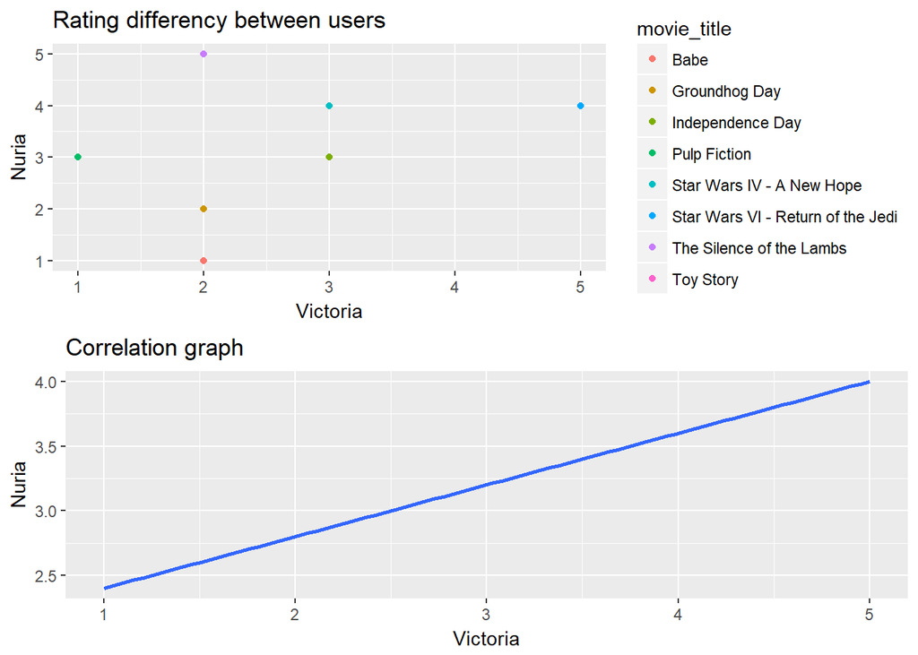

```r
#Vic - Nur
graph_VN = data_arrange('Victoria', 'Nuria')
```

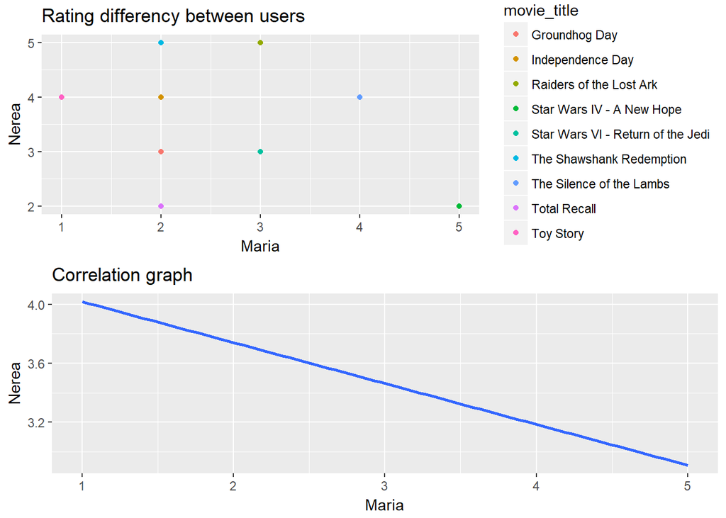

```r
#Mar - Ner
graph_MN = data_arrange('Maria', 'Nerea')
```

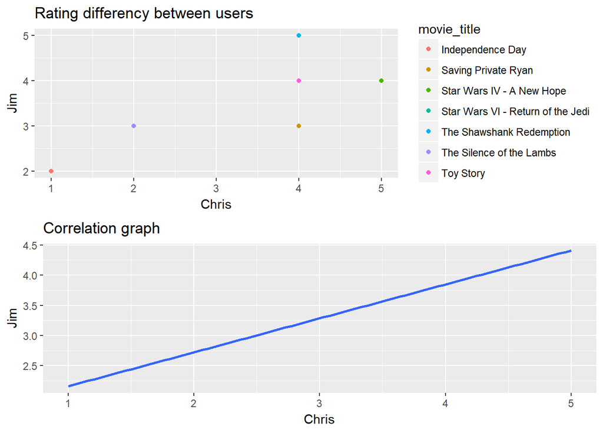

```r
#Chr - Jim
graph_CJ = data_arrange('Chris', 'Jim')
```

Interpretation:

NOTE: the correlation line for Victoria and Nuria VS Chirs and Jim, might be missing in the sense that if we do not take in consideration that axis scale, we would conclude that the have a similar correaltion when it is not the case.

```r
cat('The correlation between Victoria and Nuria is ',cor_function('Victoria', 'Nuria'),'\nThe correlation between Maria and Nerea is ',cor_function('Maria', 'Nerea'),'\nThe correlation between Chris and Jim is ', cor_function('Chris', 'Jim') )
```

```
## The correlation between Victoria and Nuria is  0.3651484
## The correlation between Maria and Nerea is  -0.3009646
## The correlation between Chris and Jim is  0.8255243
```

# 3) Top Recommendations

Get the top 5 movies recommended for Victoria. by using a weighted average of every other critic’s rankings.

**Expected result**: 3.7917013044215, ‘The Matrix’ 3.50776533175371, ‘Forrest Gump’  
3.33118834864677, ‘The Sixth Sense’ 3.11491825315719, ‘Shakespeare in Love’ 2.9124513228665, ‘Blade Runner’

```r
#select the movies that Victoria has not seen
Unsceenmovie_vic =  df %>% filter(User == 'Victoria')
Unsceenmovie_vic= Unsceenmovie_vic[, apply(Unsceenmovie_vic, 2, function(x) {is.na(x)})]
Unsceenmovie_vic = colnames(Unsceenmovie_vic)

# get the average score of Victoria
sceenmovie =  df %>% filter(User == 'Victoria')
avg_vic = rowMeans(sceenmovie[2:21], na.rm = T)

#get the mean of all the other users
sceenmovie_other =  df %>% filter(User != 'Victoria')
avg_all = rowMeans(sceenmovie_other[2:21], na.rm = T)

#user rating for the movie that Victoria did not see
Unsceenmovie_vic_other = df[-15,][Unsceenmovie_vic]

#difference between the user movie and mean users

users_diff = sweep(Unsceenmovie_vic_other,1, avg_all, FUN = "-")

#correlation:
dft <- t(df)
colnames(dft) = dft[1,]
dft = as.data.frame(dft[-1,])
dft[1:20] = sapply(dft[1:20], function(x){as.numeric(as.character(x))})


total_correlation = cor(dft, use ="pairwise.complete.obs")
Correlation_victoria = total_correlation[15,-15]

#Computing thr formula
denominator = colSums(users_diff * Correlation_victoria, na.rm = T)
numerator = sum(abs(Correlation_victoria))

final_result = (avg_vic + denominator / numerator)
head(sort(final_result, decreasing = T), n=5)
```

```
##          The Matrix        Forrest Gump     The Sixth Sense
##            3.791701            3.507765            3.331188
## Shakespeare in Love        Blade Runner
##            3.114918            2.912451
```

# 4) Top similar critics

Return the top 5 critics that are most similar to Victoria.

**Expected result**: 0.9449112, ‘Rachel’ 0.5976143, ‘Ana’ 0.5789794, ‘Oriol’ 0.4925922, ‘Maria’ 0.4273247, ‘Carles’

```r
# separate the Victoria from the other users
select_user = df %>% filter(User == 'Victoria')
not_select_user = df %>% filter(User != 'Victoria')
list_select_user = as.numeric(select_user[,2:21])
list_not_select_user = as.numeric(not_select_user[2,2:21])

#Loop to find the correlation
row = df %>% select(User) %>% filter(User != 'Victoria')
row_1 = as.vector(t(row))
list_select_user = as.numeric(select_user[,2:21])

username <-c()
cor_result <- c()

for(user in 1:(nrow(not_select_user))){
  list_not_select_user = as.numeric(not_select_user[user,2:21])
  cd = cor(list_select_user, list_not_select_user, use = 'pairwise.complete.obs')
  cor_result[user] = cd
  username[user] = row_1[user]
  }

result = data.frame(cor_result, username) #creating the results as a dataframe

#### top5

top5 = result %>% arrange(desc(cor_result)) %>% head(5)
top5
```

```
##   cor_result username
## 1  0.9449112   Rachel
## 2  0.5976143      Ana
## 3  0.5789794    Oriol
## 4  0.4925922    Maria
## 5  0.4273247   Carles
```